# Factoranalysis

# Factor- and Principal Components Analysiss

## Dataset and Packages

**R**

**Packages**

```r
library(Statamarkdown)
```

**STATA**

```stata
findit fapara
```

**Working Directory and Dataset**

```r
setwd("C:/Users/slupp/OneDrive/Skrivebord/NTNU/Mehmet/PSY8003/Factoranalysis")
workout <- readRDS("workout3.rds")
```

**STATA**

```
running C:\Users\slupp\OneDrive\Skrivebord\NTNU\Mehmet\PSY8003\Factoranalysis\p
> rofile.do . cd "C:\Users\slupp\OneDrive\Skrivebord\NTNU\Mehmet\PSY8003\Factoranalysis"
C:\Users\slupp\OneDrive\Skrivebord\NTNU\Mehmet\PSY8003\Factoranalysis
```

## Selecting the Right Number of Factors

1. Before we can extract our factors, we need to determine the right number of factors.
2. There are many ways of determining the number of factors to extract:
   1. Kaisers criterion (or other eigenvalue thresholds)
   2. Screeplot
   3. Theoretical sensitivity
   4. Good structure?
   5. Parsimony and good fit
   6. Parallel analysis
   7. etc
3. We’re going to assess these throughout (since factoranalysis is a circular process) as each fits in to our position in the process

#### Parallel Analysis

1. We will start with parallel analysis
2. Parallel Analysis is in general considered one of the best methods of determining the number of factors to extract
3. In Parallel Analysis we simulate random datasets which are similar in number of particpants and variables to our own
4. For a factor *j* to be retained we wish it to have an eigenvalue above the average of eigenvalue for factor *j,* from our randomly generated datasets.
   1. Factors are ordered from high to low eigenvalues, so we must compare them in order
5. Some have suggested using more stringent criteria, like top 95% percentile (i.e., roughly + 2 std.dev)

**R**

First we should remove all NA’s from our dataset, as most functions from the psych package assume no missing values

```r
complete_workout <- na.omit(workout)
```

```
Parallel analysis suggests that the number of factors =  2  and the number of components =  NA
```

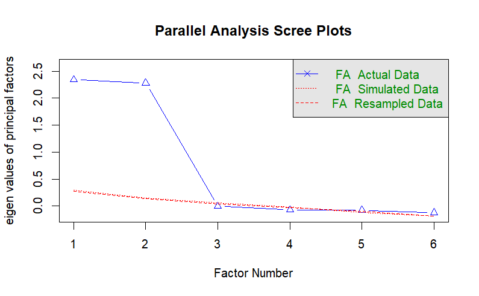

```r
library(psych)

parallel_analysis <- fa.parallel(complete_workout,
                                 fm = "pa", # Principal axis factor solution
                                 fa = "fa", # Eigenvalues from principal axis
                                 SMC = "TRUE" # Squared Multiple Correlation (i.e., R2) used as an initial estimate of communalities in the diagonal
                                 )
```

```r
print(parallel_analysis)
```

```
Call: fa.parallel(x = complete_workout, fm = "pa", fa = "fa", SMC = "TRUE")
Parallel analysis suggests that the number of factors =  2  and the number of components =  NA

 Eigen Values of

 eigen values of factors
[1]  2.34  2.28  0.00 -0.07 -0.08 -0.12

 eigen values of simulated factors
[1]  0.29  0.15  0.06 -0.02 -0.12 -0.19

 eigen values of components
[1] 2.61 2.56 0.32 0.23 0.16 0.12

 eigen values of simulated components
[1] NA
```

**STATA**

Using the fapara package and .fapara command. We must first however run a factor analysis

```
running C:\Users\slupp\OneDrive\Skrivebord\NTNU\Mehmet\PSY8003\Factoranalysis\p
> rofile.do . factor _all
(obs=194)

Factor analysis/correlation                      Number of obs    =        194
    Method: principal factors                    Retained factors =          2
    Rotation: (unrotated)                        Number of params =         11

    --------------------------------------------------------------------------
         Factor  |   Eigenvalue   Difference        Proportion   Cumulative
    -------------+------------------------------------------------------------
        Factor1  |      2.34378      0.06348            0.5390       0.5390
        Factor2  |      2.28031      2.28404            0.5244       1.0635
        Factor3  |     -0.00373      0.06681           -0.0009       1.0626
        Factor4  |     -0.07054      0.00915           -0.0162       1.0464
        Factor5  |     -0.07969      0.04239           -0.0183       1.0281
        Factor6  |     -0.12208            .           -0.0281       1.0000
    --------------------------------------------------------------------------
    LR test: independent vs. saturated:  chi2(15) =  889.42 Prob>chi2 = 0.0000

Factor loadings (pattern matrix) and unique variances

    -------------------------------------------------
        Variable |  Factor1   Factor2 |   Uniqueness
    -------------+--------------------+--------------
            Var1 |   0.8581    0.0814 |      0.2571
            Var2 |   0.9194    0.0710 |      0.1498
            Var3 |   0.8518    0.1563 |      0.2501
            Var4 |  -0.0451    0.8020 |      0.3547
            Var5 |  -0.1092    0.9141 |      0.1524
            Var6 |  -0.1511    0.8748 |      0.2119
    -------------------------------------------------


PA -- Parallel Analysis for Factor Analysis -- N = 194
PA Eigenvalues Averaged Over 25 Replications
         FA         PA          Dif
  1.    2.343784    .3150902    2.028694
  2.    2.280308    .1582924    2.122016
  3.   -.0037325    .0611057   -.0648382
  4.    -.070543    -.029235   -.0413079
  5.   -.0796921   -.1193414    .0396493
  6.   -.1220786    -.200866    .0787873
```

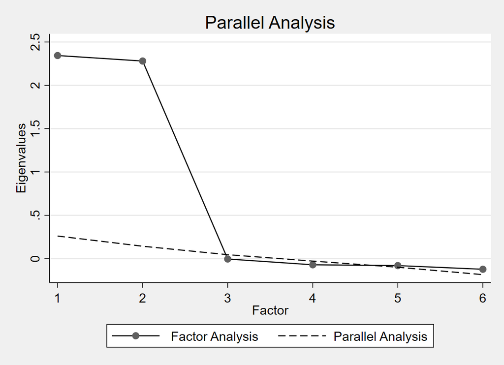

#### Average Squared Multiple Correlation

```r
square_mc <- smc(complete_workout) |> sort(decreasing = T)
square_mc
```

```
     Var2      Var5      Var6      Var3      Var1      Var4
0.7899923 0.7871944 0.7465444 0.7098107 0.7020417 0.6124627
```

```r
diff.smc <- mean(square_mc) - square_mc
diff.smc
```

```
       Var2        Var5        Var6        Var3        Var1        Var4
-0.06531790 -0.06252002 -0.02187001  0.01486364  0.02263264  0.11221165
```

**Interpretation**

1. Based on the results it seems pretty clear that a two-factor solution is appropriate
2. We can then go over to estimating our model

### Extracting Solution

**R**

1. We continue to use the psych package, and use the fa-function

```r
factor_model <- fa(complete_workout, nfactors = 2)
```